# Master 1 - Neurosciences 2025

Task design

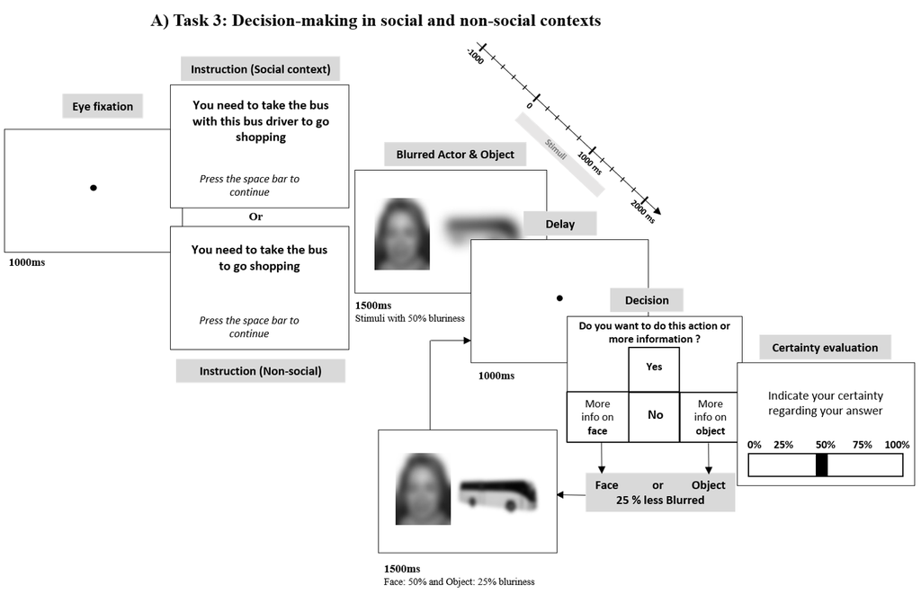

```r
knitr::include_graphics("D:/Lecture/Rstats M1/TaskDesign.png")
```

Load dataset

```r
mydata <- read.csv("D:\\Lecture\\Rstats M1\\Data_MotivaSocial.csv" , head = TRUE, sep=",")
print(mydata)
```

| sub | Engagement_tot | Engagement_social_tot | Engagement_nonsocial_tot | Info_tot | Info_social_tot | Info_nonsocial_tot | Name | subCond | Health |
| --- | --- | --- | --- | --- | --- | --- | --- | --- | --- |
| 72 | 0.3645833 | 0.4791667 | 0.2500000 | 0.31250000 | 0.29166667 | 0.33333333 | VJ37_T3 | 1 | 11 |
| 45 | 0.3125000 | 0.3750000 | 0.2500000 | 0.25000000 | 0.25000000 | 0.25000000 | SC14_T3 | 0 | 26 |
| 34 | 0.3645833 | 0.4583333 | 0.2708333 | 0.39583333 | 0.33333333 | 0.45833333 | SC02 | 0 | 27 |
| 39 | 0.3541667 | 0.3958333 | 0.3125000 | 0.20833333 | 0.20833333 | 0.20833333 | SC07_CTY02_T3 | 0 | 27 |
| 50 | 0.3437500 | 0.3333333 | 0.3541667 | 0.20833333 | 0.22916667 | 0.18750000 | SC19_T3 | 0 | 27 |
| 63 | 0.2812500 | 0.3125000 | 0.2500000 | 0.18750000 | 0.22916667 | 0.14583333 | SC32_CMI20_T3 | 0 | 27 |
| 66 | 0.3437500 | 0.4375000 | 0.2500000 | 0.22916667 | 0.22916667 | 0.22916667 | SC35_CGE24_T3 | 0 | 27 |
| 1 | 0.2708333 | 0.2500000 | 0.2916667 | 0.29166667 | 0.29166667 | 0.29166667 | AA28_T3 | 1 | 27 |
| 2 | 0.3541667 | 0.3333333 | 0.3750000 | 0.41666667 | 0.29166667 | 0.54166667 | AL36_T3 | 1 | 27 |
| 35 | 0.2812500 | 0.2708333 | 0.2916667 | 0.42708333 | 0.35416667 | 0.50000000 | SC03_CRS01_T3 | 0 | 28 |

[output cut: 56 more lines]

Load packages we will need

```r
install.packages("nortest")
library(nortest)
install.packages("ggplot2")
```

```
Error in install.packages : Updating loaded packages
```

```r
library(ggplot2)
install.packages("ggpubr")
```

```
Error in install.packages : Updating loaded packages
```

```r
library(ggpubr)
install.packages("outliers")
```

Explore data (demographic) - Example with the total information request

```r
# count patient number (same for healthy control)
cat("N(Patient) =", sum(mydata$subCond == 1), "\n")
```

```
N(Patient) = 32
```

```r
cat("N(Control) =", sum(mydata$subCond == 0), "\n")
```

```
N(Control) = 34
```

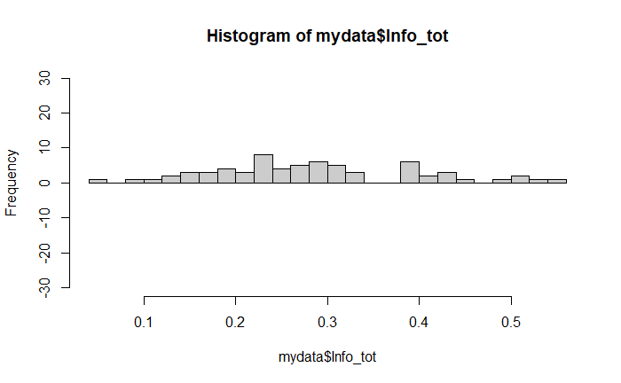

```r
# histogram distribution
h1 = hist(mydata$Info_tot, breaks=30, plot=FALSE)
plot(h1, ylim=c(-30, 30), col="gray80")
```

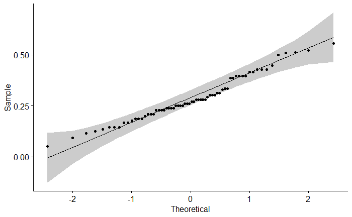

```r
# qq-plot
ggqqplot(mydata$Info_tot)
```

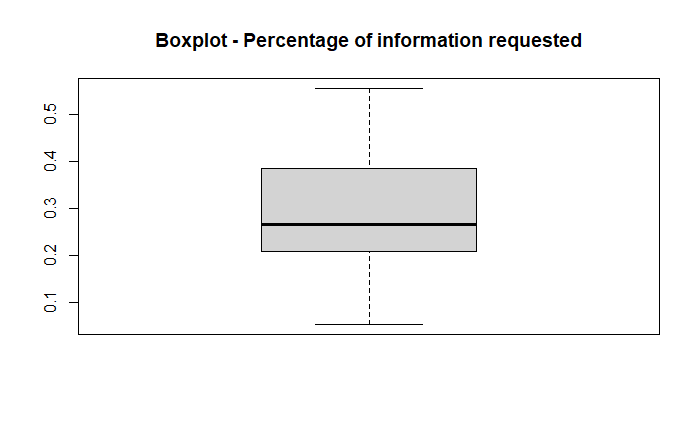

```r
# boxplot of the Percentage of information requested
boxplot(mydata$Info_tot, main = "Boxplot - Percentage of information requested")
```

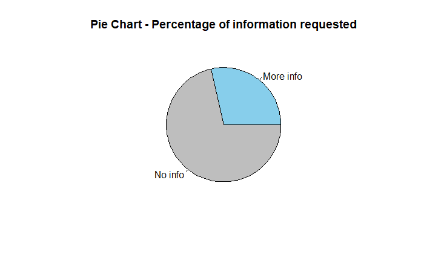

```r
# create pie chart showing mean and complementary part (to 100 for visualization)
mean_info <- mean(mydata$Info_tot, na.rm = TRUE)
other_part <- 1 - mean_info

values <- c(mean_info, other_part)
labels <- c("More info", "No info")
colors <- c("skyblue", "gray")

pie(values, labels = labels, col = colors, main = "Pie Chart - Percentage of information requested")
```

1/ Do schizophrenic patients request more information than healthy controls? We hypothesize that there is a difference in the amount of information requested between schizophrenic patients and healthy controls. We hypothesize that schizophrenic patients request less information than healthy controls due to deficits in directed exploration and increased aversion to uncertainty.

a- Assumptions check

```r
# Normality test
shapiro.test(mydata$Info_tot[mydata$subCond == 0])
```

```
    Shapiro-Wilk normality test

data:  mydata$Info_tot[mydata$subCond == 0]
W = 0.97573, p-value = 0.6349
```

```r
shapiro.test(mydata$Info_tot[mydata$subCond == 1])
```

```
    Shapiro-Wilk normality test

data:  mydata$Info_tot[mydata$subCond == 1]
W = 0.95597, p-value = 0.2124
```

```r
# Bartlett test (variance equality for two groups)
bartlett.test(mydata$Info_tot ~ mydata$subCond, data = mydata)
```

```
    Bartlett test of homogeneity of variances

data:  mydata$Info_tot by mydata$subCond
Bartlett's K-squared = 2.1017, df = 1, p-value = 0.1471
```

Conclusion, the variables meet the assumptions, they are not significantly different from a normal distribution (Shapiro-Wilk test p-value > 0.05), and their variances are equal (Bartlett test p-value > 0.05). We can perform a parametric test. The two samples are independent (the values in one sample (control sample) reveal no information about those of the other sample (schizophrenic sample)).

b- Perform statistical comparison

```r
t.test(Info_tot ~ subCond, data = mydata, var.equal = TRUE)
```

```
    Two Sample t-test

data:  Info_tot by subCond
t = -2.7037, df = 64, p-value = 0.008772
alternative hypothesis: true difference in means between group 0 and group 1 is not equal to 0
95 percent confidence interval:
 -0.12451294 -0.01869799
sample estimates:
mean in group 0 mean in group 1
      0.2500000       0.3216055
```

We can conclude that schizophrenic patients request more information than healthy controls.

c- Plot the data

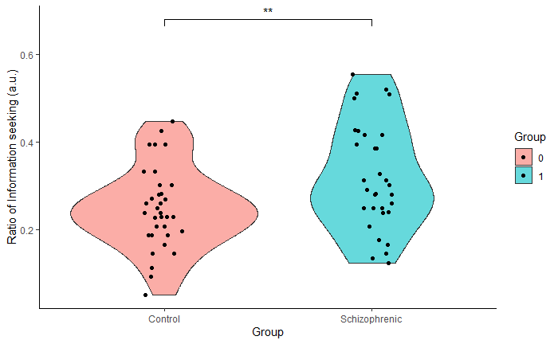

```r
library(ggplot2)
library(ggsignif)

ggplot(mydata, aes(x = factor(subCond), y = Info_tot, fill = factor(subCond))) +
  geom_violin(alpha = 0.6) +
  geom_jitter(width = 0.1) +
  scale_x_discrete(labels = c("Control", "Schizophrenic")) +
  labs(x = "Group", y = "Ratio of Information seeking (a.u.)", fill = "Group") +
  geom_signif(
    comparisons = list(c("0", "1")),
    annotations = "**",         # Use double asterisks here instead of *
    y_position = max(mydata$Info_tot, na.rm = TRUE) + 0.1,
    tip_length = 0.03
  ) +
  theme_bw() +
  theme(panel.border = element_blank(),
    panel.grid.major = element_blank(),
    panel.grid.minor = element_blank(),
    axis.line = element_line(color = "black")
  )
```

2/1. Do schizophrenic patients request more information in the social context than in the non-social context? a- Assumption check

```r
library(tidyr)
library(dplyr)

# Normality test
shapiro.test(mydata$Info_social_tot[mydata$subCond == 1])
```

```
    Shapiro-Wilk normality test

data:  mydata$Info_social_tot[mydata$subCond == 1]
W = 0.96293, p-value = 0.3297
```

```r
shapiro.test(mydata$Info_nonsocial_tot[mydata$subCond == 1])
```

```
    Shapiro-Wilk normality test

data:  mydata$Info_nonsocial_tot[mydata$subCond == 1]
W = 0.94695, p-value = 0.118
```

```r
# Subset data for subCond == 1 (Schizophrenic patient)
subset_data <- mydata %>% filter(subCond == 1)

# Convert from wide to long format
long_data <- subset_data %>%
  select(Info_social_tot, Info_nonsocial_tot) %>%
  pivot_longer(cols = c(Info_social_tot, Info_nonsocial_tot),
               names_to = "Condition",
               values_to = "InfoValue")

# Bartlett test
bartlett.test(InfoValue ~ Condition, data = long_data)
```

```
    Bartlett test of homogeneity of variances

data:  InfoValue by Condition
Bartlett's K-squared = 0.86583, df = 1, p-value = 0.3521
```

Conclusion, the variables meet the assumptions, they are not significantly different from a normal distribution (Shapiro-Wilk test p-value > 0.05), and their variances are equal (Bartlett test p-value > 0.05). We can perform a parametric test. The two samples are paired.

b- Perform statistical comparison

```r
t.test(mydata$Info_social_tot[mydata$subCond == 1],
       mydata$Info_nonsocial_tot[mydata$subCond == 1],
       paired = TRUE)
```

```
    Paired t-test

data:  mydata$Info_social_tot[mydata$subCond == 1] and mydata$Info_nonsocial_tot[mydata$subCond == 1]
t = -2.2332, df = 31, p-value = 0.03289
alternative hypothesis: true mean difference is not equal to 0
95 percent confidence interval:
 -0.083947739 -0.003806042
sample estimates:
mean difference
    -0.04387689
```

We can conclude that schizophrenic patients request more information in the non social condition than in the social condition.

c- Plot the data

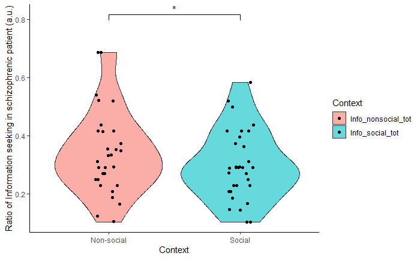

```r
library(ggplot2)
library(ggsignif)

ggplot(long_data, aes(x = factor(Condition), y = InfoValue, fill = factor(Condition))) +
  geom_violin(alpha = 0.6) +
  geom_jitter(width = 0.1) +
  scale_x_discrete(labels = c("Non-social", "Social")) +
  labs(x = "Context", y = "Ratio of Information seeking in schizophrenic patient (a.u.)", fill = "Context") +
  geom_signif(
    comparisons = list(c("Info_nonsocial_tot", "Info_social_tot")),
    annotations = "*",         # Use double asterisks here instead of *
    y_position = max(long_data$InfoValue, na.rm = TRUE) + 0.1,
    tip_length = 0.03
  ) +
  theme_bw() +
  theme(panel.border = element_blank(),
    panel.grid.major = element_blank(),
    panel.grid.minor = element_blank(),
    axis.line = element_line(color = "black")
  )
```

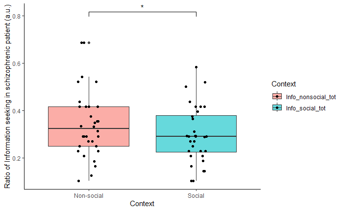

```r
library(ggplot2)
library(ggsignif)

ggplot(long_data, aes(x = factor(Condition), y = InfoValue, fill = factor(Condition))) +
  geom_boxplot(alpha = 0.6) +
  geom_jitter(width = 0.1) +
  scale_x_discrete(labels = c("Non-social", "Social")) +
  labs(x = "Context", y = "Ratio of Information seeking in schizophrenic patient (a.u.)", fill = "Context") +
  geom_signif(
    comparisons = list(c("Info_nonsocial_tot", "Info_social_tot")),
    annotations = "*",         # Use double asterisks here instead of *
    y_position = max(long_data$InfoValue, na.rm = TRUE) + 0.1,
    tip_length = 0.03
  ) +
  theme_bw() +
  theme(panel.border = element_blank(),
    panel.grid.major = element_blank(),
    panel.grid.minor = element_blank(),
    axis.line = element_line(color = "black")
  )
```

2/2. Same thing for healthy individuals?

```r
library(tidyr)
library(dplyr)

# Normality test
shapiro.test(mydata$Info_social_tot[mydata$subCond == 0])
```

```
    Shapiro-Wilk normality test

data:  mydata$Info_social_tot[mydata$subCond == 0]
W = 0.97694, p-value = 0.6742
```

```r
shapiro.test(mydata$Info_nonsocial_tot[mydata$subCond == 0])
```

```
    Shapiro-Wilk normality test

data:  mydata$Info_nonsocial_tot[mydata$subCond == 0]
W = 0.97142, p-value = 0.5017
```

```r
# Subset data for subCond == 0 (controls)
subset_data <- mydata %>% filter(subCond == 0)

# Convert from wide to long format
long_data <- subset_data %>%
  select(Info_social_tot, Info_nonsocial_tot) %>%
  pivot_longer(cols = c(Info_social_tot, Info_nonsocial_tot),
               names_to = "Condition",
               values_to = "InfoValue")

# Bartlett test
bartlett.test(InfoValue ~ Condition, data = long_data)
```

```
    Bartlett test of homogeneity of variances

data:  InfoValue by Condition
Bartlett's K-squared = 1.1887, df = 1, p-value = 0.2756
```

```r
# perform comparison
t.test(mydata$Info_social_tot[mydata$subCond == 0],
       mydata$Info_nonsocial_tot[mydata$subCond == 0],
       paired = TRUE)
```

```
    Paired t-test

data:  mydata$Info_social_tot[mydata$subCond == 0] and mydata$Info_nonsocial_tot[mydata$subCond == 0]
t = -0.901, df = 33, p-value = 0.3741
alternative hypothesis: true mean difference is not equal to 0
95 percent confidence interval:
 -0.03992713  0.01541732
sample estimates:
mean difference
     -0.0122549
```

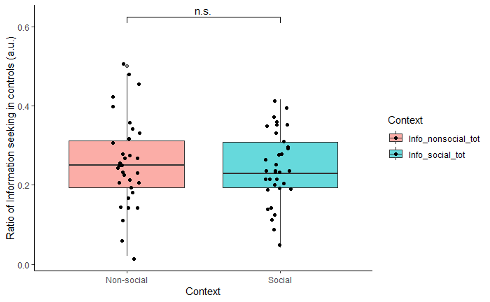

```r
# plot the comparison
ggplot(long_data, aes(x = factor(Condition), y = InfoValue, fill = factor(Condition))) +
  geom_boxplot(alpha = 0.6) +
  geom_jitter(width = 0.1) +
  scale_x_discrete(labels = c("Non-social", "Social")) +
  labs(x = "Context", y = "Ratio of Information seeking in controls (a.u.)", fill = "Context") +
  geom_signif(
    comparisons = list(c("Info_nonsocial_tot", "Info_social_tot")),
    annotations = "n.s.",         # Use double asterisks here instead of *
    y_position = max(long_data$InfoValue, na.rm = TRUE) + 0.1,
    tip_length = 0.03
  ) +
  theme_bw() +
  theme(panel.border = element_blank(),
    panel.grid.major = element_blank(),
    panel.grid.minor = element_blank(),
    axis.line = element_line(color = "black")
  )
```

2/3. ANOVA two-factors

```r
library(tidyr)
library(dplyr)
library(car)

# Convert from wide to long format
long_data <- mydata %>%
  select(sub, subCond, Info_social_tot, Info_nonsocial_tot) %>%
  pivot_longer(cols = c(Info_social_tot, Info_nonsocial_tot),
               names_to = "Condition", values_to = "Score")

# Ensure factors
long_data <- long_data %>%
  mutate(subCond = factor(subCond),
         Condition = factor(Condition))

# Check the homogeneity of variances across the different groups defined by your factors
leveneTest(Score ~ Condition*subCond, data = long_data)
```

```
Levene's Test for Homogeneity of Variance (center = median)
       Df F value Pr(>F)
group   3  1.2384 0.2986
      128
```

```r
# Two-way ANOVA
anova_model <- aov(Score ~ subCond * Condition + (1|sub), data = long_data)
summary(anova_model)
```

```
                   Df Sum Sq Mean Sq F value   Pr(>F)
subCond             1 0.1601 0.16013  11.833 0.000786 ***
Condition           1 0.0251 0.02511   1.856 0.175495
subCond:Condition   1 0.0082 0.00824   0.609 0.436580
Residuals         128 1.7321 0.01353
---
Signif. codes:  0 ‘***’ 0.001 ‘**’ 0.01 ‘*’ 0.05 ‘.’ 0.1 ‘ ’ 1
```

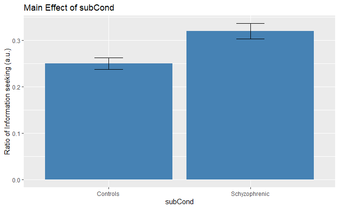

```r
library(ggplot2)
library(dplyr)

# Aggregate means by subCond
mean_subCond <- long_data %>%
  group_by(subCond) %>%
  summarize(mean_Score = mean(Score), sd = sd(Score), n = n()) %>%
  mutate(se = sd / sqrt(n))

ggplot(mean_subCond, aes(x = subCond, y = mean_Score)) +
  geom_bar(stat = "identity", fill = "steelblue") +
  geom_errorbar(aes(ymin = mean_Score - se, ymax = mean_Score + se), width = 0.2) +
  labs(title = "Main Effect of subCond", y = "Ratio of Information seeking (a.u.)") +
  scale_x_discrete(labels = c("Controls", "Schyzophrenic"))
```

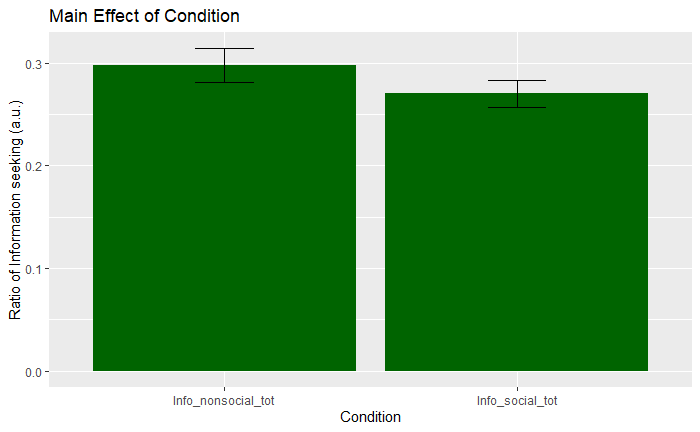

```r
# Aggregate means by Condition
mean_Condition <- long_data %>%
  group_by(Condition) %>%
  summarize(mean_Score = mean(Score), sd = sd(Score), n = n()) %>%
  mutate(se = sd / sqrt(n))

ggplot(mean_Condition, aes(x = Condition, y = mean_Score)) +
  geom_bar(stat = "identity", fill = "darkgreen") +
  geom_errorbar(aes(ymin = mean_Score - se, ymax = mean_Score + se), width = 0.2) +
  labs(title = "Main Effect of Condition", y = "Ratio of Information seeking (a.u.)")
```

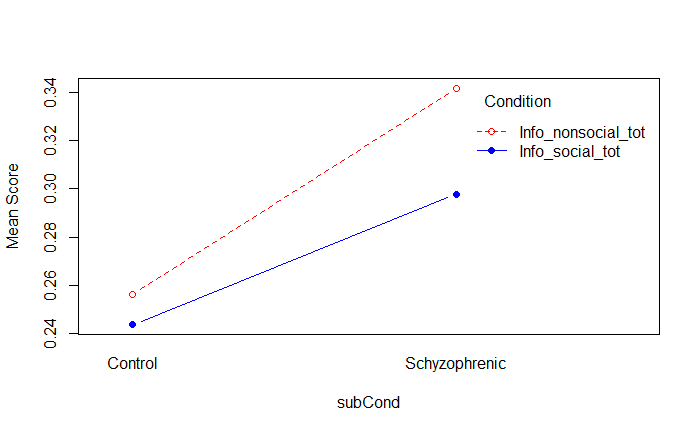

```r
levels(long_data$subCond) <- c("Control", "Schyzophrenic")
interaction.plot(x.factor = long_data$subCond,
                 trace.factor = long_data$Condition,
                 response = long_data$Score,
                 fun = mean,
                 type = "b",
                 xlab = "subCond",
                 ylab = "Mean Score",
                 trace.label = "Condition",
                 col = c("red", "blue"),
                 pch = c(1, 19))
```

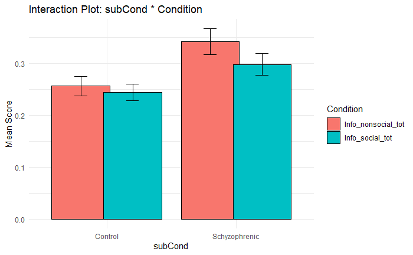

```r
library(ggplot2)
library(dplyr)

# Calculate means and standard errors for each subCond * Condition combination
interaction_means <- long_data %>%
  group_by(subCond, Condition) %>%
  summarize(mean_Score = mean(Score), sd = sd(Score), n = n()) %>%
  mutate(se = sd / sqrt(n))
# Plot interaction as grouped bar graph
ggplot(interaction_means, aes(x = subCond, y = mean_Score, fill = Condition)) +
  geom_bar(stat = "identity", position = position_dodge(width = 0.8), color = "black") +
  geom_errorbar(aes(ymin = mean_Score - se, ymax = mean_Score + se),
                position = position_dodge(width = 0.8), width = 0.2) +
  labs(title = "Interaction Plot: subCond * Condition",
       x = "subCond",
       y = "Mean Score") +
  theme_minimal()
```

3/ Is mental well-being linked to the overall information-seeking behavior?

```r
# Normality test
shapiro.test(mydata$Info_tot)
```

```
    Shapiro-Wilk normality test

data:  mydata$Info_tot
W = 0.96927, p-value = 0.1007
```

```r
shapiro.test(mydata$Health)
```

```
    Shapiro-Wilk normality test

data:  mydata$Health
W = 0.96018, p-value = 0.03289
```

```r
res <- cor.test(mydata$Info_tot, mydata$Health, method = "spearman")
print(res)
```

```
    Spearman's rank correlation rho

data:  mydata$Info_tot and mydata$Health
S = 60645, p-value = 0.0309
alternative hypothesis: true rho is not equal to 0
sample estimates:
       rho
-0.2659529
```

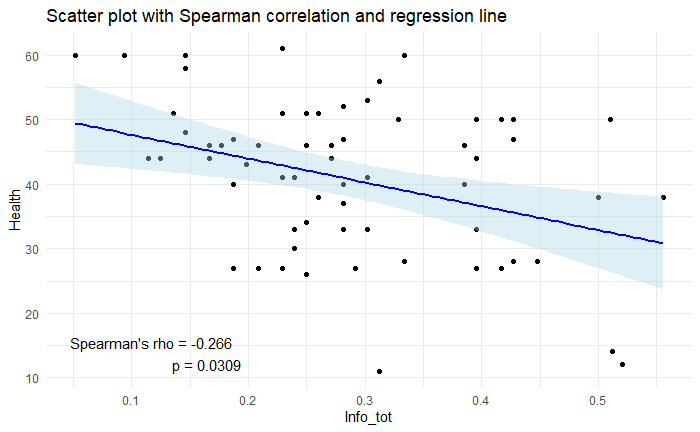

```r
library(ggplot2)
# Plot with points, regression line, confidence interval, and annotation of Spearman rho
ggplot(mydata, aes(x = Info_tot, y = Health)) +
  geom_point() +
  geom_smooth(method = "lm", color = "blue", fill = "lightblue", se = TRUE) +  # regression line + 95% CI
  annotate("text", x = 0.2, y = -Inf, hjust = 1.1, vjust = -0.5,
           label = paste0("Spearman's rho = ", round(res$estimate, 3), "\n",
                          "p = ", signif(res$p.value, 3)),
           size = 4) +
  labs(title = "Scatter plot with Spearman correlation and regression line",
       x = "Info_tot",
       y = "Health") +
  theme_minimal()
```

Summarizing the mean and STD/SEM for all the group and variables

```r
library(dplyr)
library(tidyr)

sem <- function(x) {
  sd(x, na.rm = TRUE) / sqrt(sum(!is.na(x)))
}

vars_to_summarize <- c("Engagement_tot", "Engagement_nonsocial_tot", "Engagement_social_tot",
                       "Info_tot", "Info_nonsocial_tot", "Info_social_tot")

Data_summarized <- mydata %>%
  select(all_of(vars_to_summarize), subCond) %>%
  pivot_longer(cols = all_of(vars_to_summarize), names_to = "Variable", values_to = "Value")

# Summarize full sample and add sample name to variable
summary_full <- Data_summarized %>%
  group_by(Variable) %>%
  summarise(
    mean = mean(Value, na.rm = TRUE),
    std = sd(Value, na.rm = TRUE),
    sem = sem(Value),
    min = min(Value, na.rm = TRUE),
    max = max(Value, na.rm = TRUE)
  ) %>%
  mutate(Variable = paste(Variable, "(Full Sample)"))

# Summarize subset subCond == 1 and add sample name to variable
summary_subcond1 <- Data_summarized %>%
  filter(subCond == 1) %>%
  group_by(Variable) %>%
  summarise(
    mean = mean(Value, na.rm = TRUE),
    std = sd(Value, na.rm = TRUE),
    sem = sem(Value),
    min = min(Value, na.rm = TRUE),
    max = max(Value, na.rm = TRUE)
  ) %>%
  mutate(Variable = paste(Variable, "(Schyzophrenic)"))

# Summarize subset subCond == 0 and add sample name to variable
summary_subcond0 <- Data_summarized %>%
  filter(subCond == 0) %>%
  group_by(Variable) %>%
  summarise(
    mean = mean(Value, na.rm = TRUE),
    std = sd(Value, na.rm = TRUE),
    sem = sem(Value),
    min = min(Value, na.rm = TRUE),
    max = max(Value, na.rm = TRUE)
  ) %>%
  mutate(Variable = paste(Variable, "(Healthy control)"))

# Combine (stack) summaries
summary_combined <- bind_rows(summary_full, summary_subcond1, summary_subcond0) %>%
  arrange(Variable)

print(summary_combined)
```

| Variable | mean | std | sem | min | max |
| --- | --- | --- | --- | --- | --- |
| Engagement_nonsocial_tot (Full Sample) | 0.2854416 | 0.08940497 | 0.01100499 | 0.14583333 | 0.7500000 |
| Engagement_nonsocial_tot (Healthy control) | 0.2726716 | 0.06141046 | 0.01053181 | 0.16666667 | 0.4375000 |
| Engagement_nonsocial_tot (Schyzophrenic) | 0.2990098 | 0.11125015 | 0.01966643 | 0.14583333 | 0.7500000 |
| Engagement_social_tot (Full Sample) | 0.3366742 | 0.11931605 | 0.01468679 | 0.12500000 | 0.8541667 |
| Engagement_social_tot (Healthy control) | 0.3431373 | 0.09841912 | 0.01687874 | 0.12500000 | 0.5000000 |
| Engagement_social_tot (Schyzophrenic) | 0.3298071 | 0.13944392 | 0.02465043 | 0.12500000 | 0.8541667 |
| Engagement_tot (Full Sample) | 0.3111404 | 0.09648241 | 0.01187616 | 0.13541667 | 0.8020833 |
| Engagement_tot (Healthy control) | 0.3079044 | 0.06943771 | 0.01190847 | 0.14583333 | 0.4687500 |
| Engagement_tot (Schyzophrenic) | 0.3145787 | 0.11984244 | 0.02118535 | 0.13541667 | 0.8020833 |
| Info_nonsocial_tot (Full Sample) | 0.2975834 | 0.13237353 | 0.01629405 | 0.02083333 | 0.6875000 |

[output cut: 8 more lines]

Choose the adequat statistical test

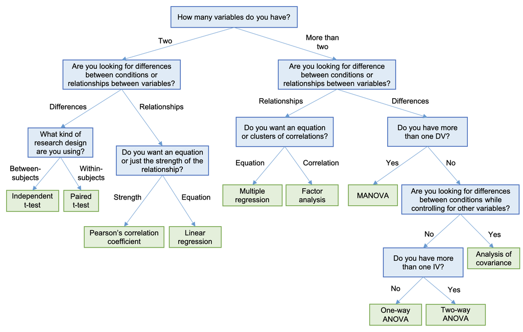

```r
knitr::include_graphics("D:/Lecture/Rstats M1/stats_tests_tree.png")
```